# MB5370 Marine Genomics - Workshop 3

Metagenome Assembly

Author

Katie Dyck

Published

July 9, 2026

**Note**

In this document, all yellow code chunks indicate bash (R Terminal) code input. Comments begin with `#`; these are listed for reference only, and should not be entered into the Terminal.

All other code chunks indicate R code, which should be input into the Console.

In this workshop we will assemble a mock metagenome consisting of five bacterial species. This is very simple compared with a real metagenome, but has been designed to capture some key challenges that appear in metagenome assembly:

- **Variable coverage**: Some species are abundant, some are quite rare. It is more difficult to assemble rarer taxa.
- **Similar sequences**: This community has two *Vibrio* species. They are similar enough that they are difficult to separate in an assembly.

The table below shows the relative abundance (`Proportion of Reads`) of each species in our mock community. Since this is a mock community we already have reference genomes for each member. Information on each genome can be found by typing its accession (eg. ASM31704v1) into the search field on the [NCBI database of microbial genomes](https://www.ncbi.nlm.nih.gov/datasets/genome/?taxon=2157,2).

For the purposes of metagenomic assembly we note the number of chromosomes, total genome size and its GC content. We will use these pieces of information later to assess our preliminary assembly results.

[output not shown]

## 1 Workshop outline

1. Examine reads
2. Assembly
3. Basic assembly QC
4. Binning
5. Bin assessment

## 2 Step 1: Examine Reads

Input data for this exercise consists of simulated reads from an Oxford Nanopore MinION sequencer.

```bash
mkdir workshop3
cd workshop3

# Make a new subdirectory, raw_reads
mkdir raw_data
cd raw_data
ln -s /pvol/data/metagenome_assembly/reads_R10_0.5.fastq.gz raw_reads.fastq.gz

# Change directory back "up"
cd ..
```

```bash
ls -lR
```

### 2.1 Read Length Distribution

During the assembly process we will take shorter sequences (reads) and attempt to join them together into longer sequences. One of the most important determinants of success in this process is the size of the raw reads themselves. Our starting point for this assembly is to examine the read length distribution in our input data.

```bash
zcat raw_data/raw_reads.fastq.gz | head -n 40000 | bioawk -c fastx '{print $name,length($seq)}' > read_lengths.txt
```

Now we’ll create a plot to visualize these lengths.

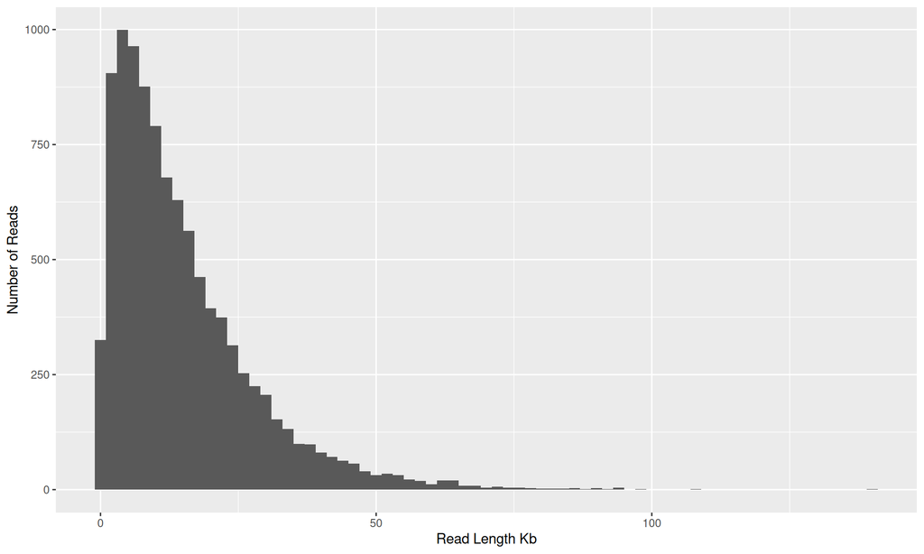

```r
library(tidyverse)
rl_data <- read_tsv("../workshop3/read_lengths.txt", col_names = c("id", "length"), show_col_types = FALSE)

ggplot(rl_data, aes(x = length/1000)) +
  geom_histogram(binwidth = 2) +
  xlab("Read Length Kb") +
  ylab("Number of Reads")
```

### 2.2 Calculating read N50

From this plot it is clear that the majority of reads are between 1 and 50kb in length. A good way to summarise this is the N50 statistic. Although N50 is most often used to summarise genome assemblies it’s also very useful for summarising read length distributions. This statistic is useful is because it is unaffected by having a large number of tiny reads and instead places greatest emphasis on the longer reads in the data. Let’s calculate the read N50 for our sample of reads.

- Step 1: Rank all reads from longest to shortest
- Step 2: Create a new column with the cumulative sum of read lengths (starting from longest read).
- Step 3: Find the read at which the cumulative sum surpasses 50% of the total read volume (ie total sum of all read lengths)

```r
total_len <- sum(rl_data$length)

rl_data %>%
  # Arrange reads by length in descending order
  arrange(desc(length)) %>%
  # Calculate cumulative sum for each successive read
  mutate(cumsum = cumsum(length)) %>%
  filter(cumsum>total_len/2) %>%
  head(n=1)
```

| id | length | cumsum |
| --- | --- | --- |
| c96c1300-8177-e260-d9bd-2fdf75d0146b_2040 | 22322 | 74486252 |

The N50 of the individual reads is ~ 22Kb. Keep this in mind as we assemble the reads. We expect that the N50 of our assembly should be much greater than this.

## 3 Step 2: Assembly

We will use `flye` for this.

```bash
mkdir flye
cd flye
```

Create a new shell script, `run_flye.sh`, in the `flye` directory with the following code:

```bash
#!/bin/bash
#SBATCH --time=360
#SBATCH --ntasks=8 --mem=4gb

echo "Starting flye in $(pwd) at $(date)"

flye --nano-hq ../raw_data/raw_reads.fastq.gz --threads 8 --out-dir mock --meta

echo "Finished flye in $(pwd) at $(date)"
```

```bash
# Submit job
sbatch run_flye.sh

squeue  # check JOBID for next command

# Monitor job output
tail -f slurm-XXX.out   # replace XXX with JOBID
```

Outputs will be available in directory `mock`. Key output files are:

| **File** | **Description** |
| --- | --- |
| assembly.fasta | The actual assembled contigs |
| assembly_graph.gfa | Representation of the assembly graph in gfa format |
| assembly_graph.gv | Assembly graph in graphviz format |
| assembly_info.txt | Table of information on each contig |

(*Export “assembly.fasta” file and open in Bandage to view contigs.*)

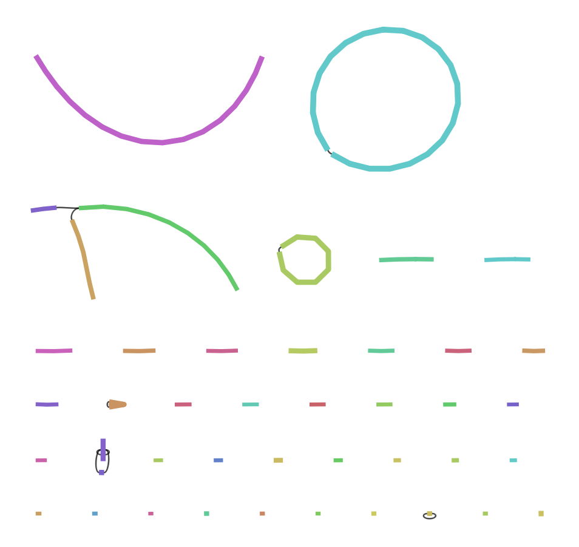

**Observations**:

- Largest contig at the top (contig 29) = 4,681,059 bp; depth 21x. Looks like this contig corresponds to the genome of the most abundant species in our mock community.
- Contig 2 (top left corner) could also be a genome from our mock community (3,179,384 bp; depth 15x).
- Contig 29 and 42 are chromosomes - we know this because they are circular (i.e. connected to themselves).
- Contig 38 (*tall purple contig connected to itself and contiguous 39, second row from the bottom*) must be a repeat - it has a length of only 521 bp but a depth of 769x!
- Contig 10 (*third row, connected to itself*) is interesting: 320,081 bp, depth 14x.

### 3.1 Chromosome lengths and GC content in the reference data

We want to compare the assembled contigs (from the flye output) with reference genomes from the 5 species that compromise our mock community. We will do this by *tabulating chromosome lengths and their corresponding GC content*.

Make a new text file called “gc.awk” with the code in the chunk below and save it in the top level of the project directory (`workshop3` folder in this case).

```bash
# Bioawk script for calculating gc and printing name,length,size
BEGIN {
    OFS="\t"
}

{
    l=length($seq)
    ngc=gsub("[cgCG]","",$seq)
    nat=gsub("[taTA]","",$seq)
    print $name,l,ngc/(ngc+nat)
}
```

```bash
# Look at reference genomes from our mock community
ls /pvol/data/mg/refs/*.fna
```

Use the `gc.awk` file we made to print the GC content and contig lengths for all chromosomes in these files. Use ‘cat’ to concatenate all the files together and then use a pipe to send their contents to our bioawk program.

```bash
cd ..
cat /pvol/data/mg/refs/*.fna | bioawk -c fastx -f gc.awk
```

CP003591.1 4681111 0.584631  
CP045504.1 4388462 0.636383  
CP045505.1 51725 0.578966  
AP024165.1 3168162 0.44373  
AP024166.1 1553697 0.438144  
AP024167.1 320083 0.418301  
AP024168.1 221076 0.434733  
CP098033.1 1819821 0.445875  
CP098034.1 3294375 0.447314  
CP098035.1 36224 0.485231  
NZ_CP053351.1 4560973 0.34633